# **Loan Data Exploration**

## **Data and Investigation Overview**

Here, I explore a dataset containing over 600 loan application decision as well as loan application attributes per applicant.In this investigation, I wanted to look at some attributes of the portfolio of these loan applicants that could be used to predict whether or not the loan application would be approved. The main focus was:

1. Gender of the applicant
2. Number of Dependents the applicants have - if they have any
3. The education level of the applicants
4. Whether or not the applicant is Self-Employed
5. Whether or not the applicant has a credit history
6. The neighborhood the person lives in

I think the dataset is clean enough for exploration

## **Data Exploration**

#### **Variables of Interest**

I am interested in figuring out what features/variables are best for predicting the decision of a loan application - Yes or No. I expect that `Credit_History`, `LoanAmount`, `Loan_Amount_Term`, `CoapplicantIncome`, `ApplicantIncome`, `TotalIncome`, `Education`, `Property Area` would have the most effect on the decision. However, this is just a hypothesis that must be validated

### **Univariate Exploration**

I'd start by looking at the distribution of the features I think are most important. Let's check the distribution of the response variable.

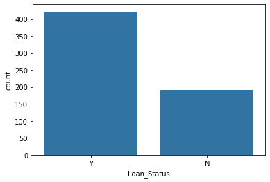

```python
base_color = sns.color_palette()[0]
sns.countplot(data = train_clean,  x = "Loan_Status", color = base_color);
```

We see that majority of the applicants got their loans approved. However, a large number also were denied. Let's check out the distribution of certain variables. We'd start with `Credit_History`.

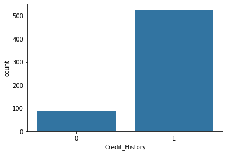

```python
base_color = sns.color_palette()[0]
sns.countplot(data = train_clean,  x = "Credit_History", color = base_color);
```

This is interesting as many of the applicants had credit history. This is truly an important variable. Next, I check the loan amount.

```python
train_clean.Loan_Amount_Term.value_counts()
```

```
360    526
180     44
480     15
300     13
240      4
84       4
120      3
60       2
36       2
12       1
Name: Loan_Amount_Term, dtype: int64
```

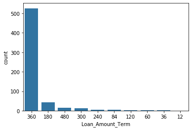

```python
base_color = sns.color_palette()[0]
sorted_order = train_clean.Loan_Amount_Term.value_counts().index
sns.countplot(data = train_clean,  x = "Loan_Amount_Term", color = base_color, order = sorted_order);
```

The most common loan term was 360 months. That's surprising tho. Next we check the co-applicant, applicant and total incomes.

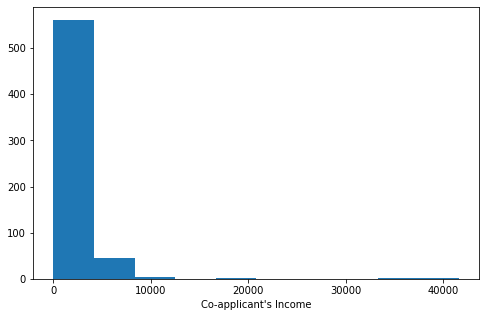

```python
plt.figure(figsize=[8, 5])
plt.hist(data = train_clean, x = "CoapplicantIncome")
plt.xlabel("Co-applicant's Income")
plt.show()
```

The distribution above doesn't really tell us much about the distribution. Going forward, I am going to perform logarithmic transformations on all Income variables

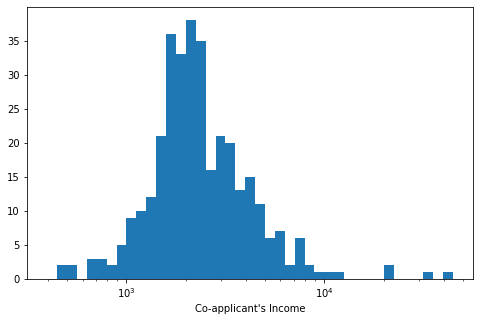

```python
log_binsize = 0.05
bins = 10 ** np.arange(2.6, np.log10(train_clean["CoapplicantIncome"].max())+log_binsize, log_binsize)

plt.figure(figsize=[8, 5])
plt.hist(data = train_clean, x = "CoapplicantIncome", bins = bins)
plt.xscale('log')
plt.xlabel("Co-applicant's Income")
plt.show()
```

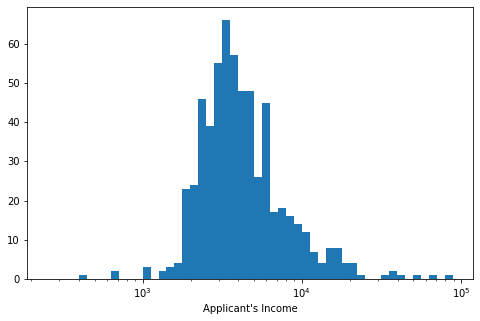

```python
log_binsize = 0.05
bins = 10 ** np.arange(2.4, np.log10(train_clean["ApplicantIncome"].max())+log_binsize, log_binsize)

plt.figure(figsize=[8, 5])
plt.hist(data = train_clean, x = "ApplicantIncome", bins = bins)
plt.xscale('log')
plt.xlabel("Applicant's Income")
plt.show()
```

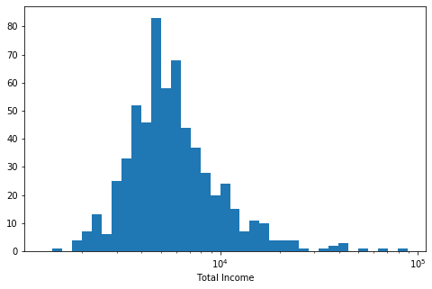

```python
log_binsize = 0.05
bins = 10 ** np.arange(3.1, np.log10(train_clean["TotalIncome"].max())+log_binsize, log_binsize)

plt.figure(figsize=[8, 5])
plt.hist(data = train_clean, x = "TotalIncome", bins = bins)
plt.xscale('log')
plt.xlabel("Total Income")
plt.show()
```

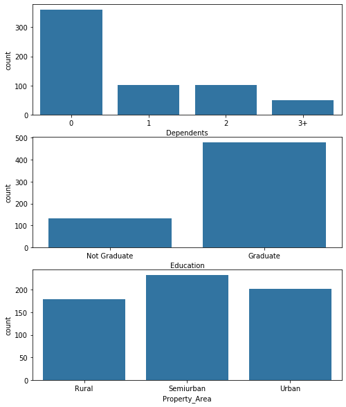

```python
# let's plot all three ordinal variable's distribution.

fig, ax = plt.subplots(nrows=3, figsize = [8,10])

base_color = sns.color_palette()[0]
sns.countplot(data = train_clean, x = "Dependents", color = base_color, ax = ax[0])
sns.countplot(data = train_clean, x = "Education", color = base_color, ax = ax[1])
sns.countplot(data = train_clean, x = "Property_Area", color = base_color, ax = ax[2])

plt.show()
```

### **Bivariate Exploration**

To start off with, I want to look at the pairwise correlations present between features in the data.

```python
train_clean.info()
```

```
<class 'pandas.core.frame.DataFrame'>
RangeIndex: 614 entries, 0 to 613
Data columns (total 13 columns):
 #   Column             Non-Null Count  Dtype
---  ------             --------------  -----
 0   Gender             614 non-null    object
 1   Married            614 non-null    object
 2   Dependents         614 non-null    category
 3   Education          614 non-null    category
 4   Self_Employed      614 non-null    object
 5   ApplicantIncome    614 non-null    int64
 6   CoapplicantIncome  614 non-null    int32
 7   LoanAmount         614 non-null    int32
 8   Loan_Amount_Term   614 non-null    int32
 9   Credit_History     614 non-null    int32
 10  Property_Area      614 non-null    category
 11  Loan_Status        614 non-null    object
 12  TotalIncome        614 non-null    int64
dtypes: category(3), int32(4), int64(2), object(4)
memory usage: 40.7+ KB
```

```python
numeric_variables = ["ApplicantIncome", "CoapplicantIncome", "TotalIncome", "LoanAmount", "Loan_Amount_Term"]
ordinal_variables = ["Dependents", "Education", "Property_Area"]
nominal_variables = ["Gender", "Married", "Self_Employed", "Credit_History" ]
```

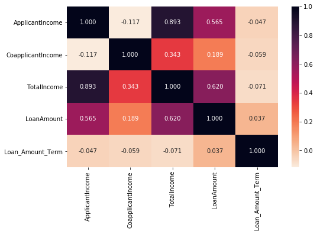

```python
# correlation plot
plt.figure(figsize = [8, 5])
sns.heatmap(train_clean[numeric_variables].corr(), annot = True, fmt = '.3f',
           cmap = "rocket_r")
plt.show()
```

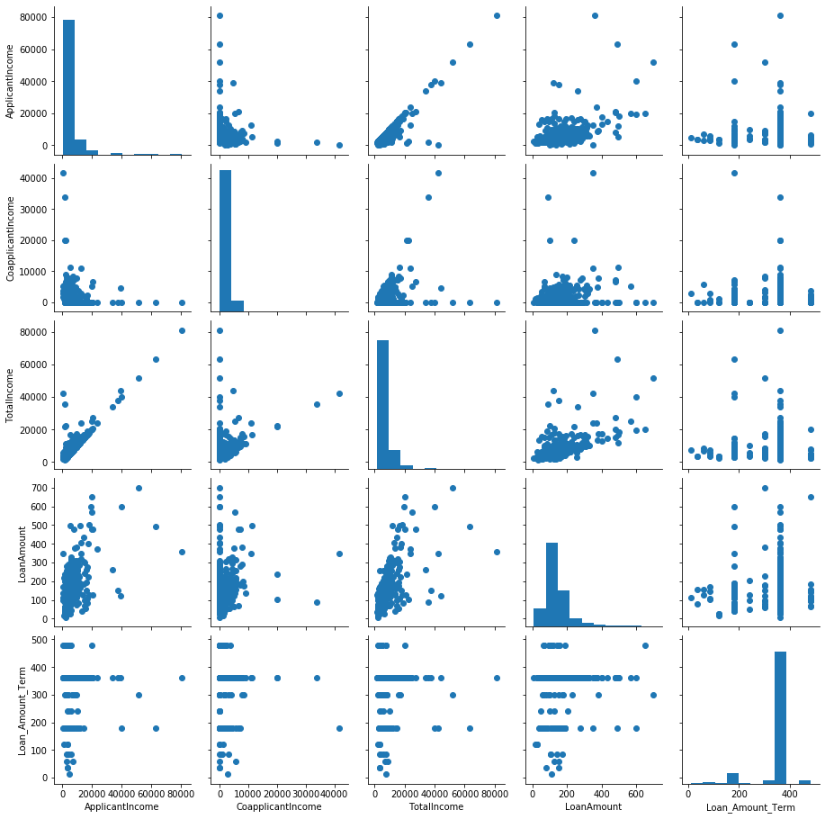

```python
# scatterplot for numeric variables
plot = sns.PairGrid(data = train_clean, vars = numeric_variables)
plot = plot.map_offdiag(plt.scatter);
plot.map_diag(plt.hist)
```

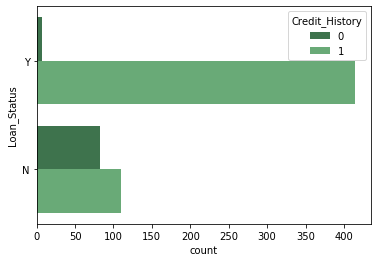

```python
sns.countplot(y = "Loan_Status", hue = "Credit_History", data = train_clean, palette = "Greens_d");
```

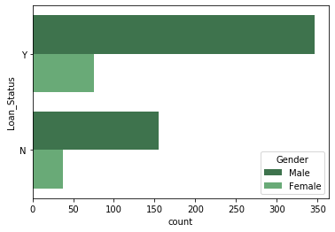

```python
sns.countplot(y = "Loan_Status", hue = "Gender", data = train_clean, palette = "Greens_d");
```

As seen above, it looks like Men are likely to have loans accepted. However, we need to consider what proportions of applicants are Male and Female

```python
train_clean.Loan_Status.value_counts()
```

```
Y    422
N    192
Name: Loan_Status, dtype: int64
```

```python
train_clean.Gender.value_counts()
```

```
Male      502
Female    112
Name: Gender, dtype: int64
```

```python
prop_male = len(train_clean[(train_clean["Gender"] == "Male") & (train_clean["Loan_Status"] == "Y")])/len(train_clean[train_clean["Loan_Status"] =="Y"])
prop_male
```

```
0.8222748815165877
```

```python
prop_female = len(train_clean[(train_clean["Gender"] == "Female") & (train_clean["Loan_Status"] == "Y")])/len(train_clean[train_clean["Loan_Status"] =="Y"])
prop_female
```

```
0.17772511848341233
```

Truly, more Males had their loan applications approved than females.

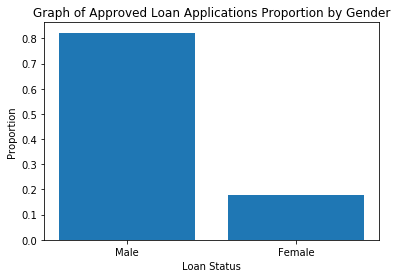

```python
male_and_female = pd.DataFrame([prop_male, prop_female])
plt.bar(x = ["Male", "Female"], height = [prop_male, prop_female])
plt.xlabel("Loan Status")
plt.ylabel("Proportion")
plt.xticks(["Male", "Female"])
plt.title("Graph of Approved Loan Applications Proportion by Gender");
```

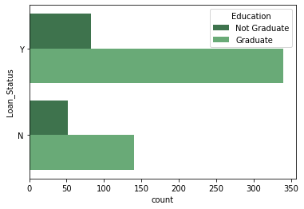

```python
sns.countplot(y = "Loan_Status", hue = "Education", data = train_clean, palette = "Greens_d");
```

From the plot above, we can see that people who are graduates are likely to have loans accepted. This is understandable as people who are educated are most likely well paid and are likely to repay loans.

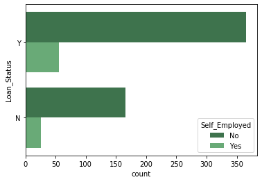

```python
sns.countplot(y = "Loan_Status", hue = "Self_Employed", data = train_clean, palette = "Greens_d");
```

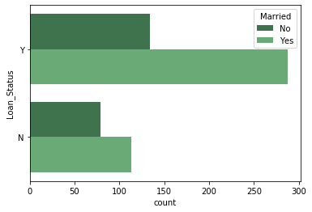

```python
sns.countplot(y = "Loan_Status", hue = "Married", data = train_clean, palette = "Greens_d");
```

As you can see, people who are married are likely to get loans when compared to people who are not married. This could be because they have a higher family income = applicant income + coapplicant income

Let us investigate.

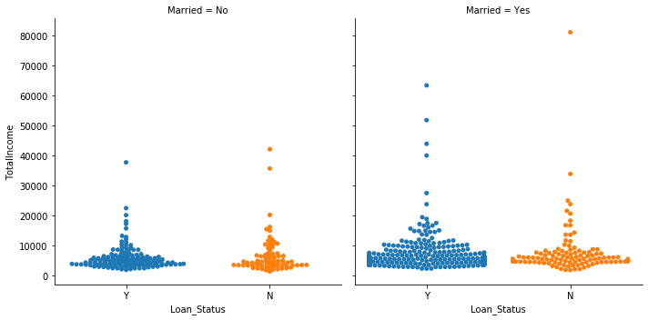

```python
sns.factorplot(x = "Loan_Status", y = "TotalIncome",
               col = "Married", data = train_clean, kind = "swarm");
```

Well, not really.

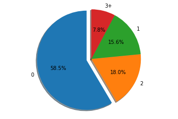

```python
loan_approved = train_clean[train_clean["Loan_Status"] == "Y"]
approved_dependents = loan_approved["Dependents"]
prop = (approved_dependents.value_counts()/len(loan_approved))*100

explode = (0.1, 0, 0, 0)

fig1, ax1 = plt.subplots()
ax1.pie(prop, explode=explode, labels=prop.index, autopct='%1.1f%%', shadow=True, startangle=90)
ax1.axis('equal')  # Equal aspect ratio ensures that pie is drawn as a circle.

plt.show()
```

From both the pie chart and the bar chart shown above, we see that 58.5% of all approved applications had no dependents. This is quite understandable because it is believed that the more dependants, the more responsibility an individual has. This decreases their chances of paying back the loan.

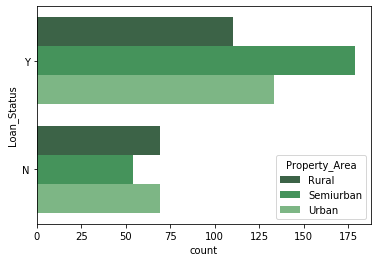

```python
sns.countplot(y= "Loan_Status", hue = "Property_Area", data = train_clean, palette = "Greens_d");
```

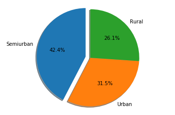

```python
approved_area = loan_approved["Property_Area"]
prop_area = (approved_area.value_counts()/len(loan_approved))*100

explode = (0.1, 0, 0)

fig1, ax1 = plt.subplots()
ax1.pie(prop_area, explode=explode, labels=prop_area.index, autopct='%1.1f%%', shadow=True, startangle=90)
ax1.axis('equal')  # Equal aspect ratio ensures that pie is drawn as a circle.

plt.show()
```

It looks like people in semi urban areas were more likely to be given loans when compared to other property areas.